# Practicum II / Part A

DA5030 / Decision Tree & Logisti Regression Classification

Larkin, Yvonne

# Part A : Practicum Goal

Create a heterogeneous model made up of a homogeneous logistic regression and pair with a homogeneous random forest model predict the feature `DONATED`.

## 1. Load Packages

```r
library(ggplot2)
library(knitr)
library(caret)
library(randomForest)
```

## 1.2 Load Data

Extracted data file `donations-salted.csv` from the compressed file linked donations-salted.csv.zip to locally load data to a data.frame in the R Project. The file has headers, is comma delimited, and has both `numeric` and `character` string class data entries. Use `read.csv( )` to load file into a data.frame `df`.

There are only 4 `character` features and 1 `logical` features that would be affected by `stringsAsFactors`, but I will load the data with the parameter `FALSE` to allow for viewing the file as is, avoid the need to undo any factor leveling, and have more control proceeding. I did explore both `TRUE` and `FALSE` loading, overall I think that avoiding the need to change factor levels is easier than starting with them. Especially for ordinal features.

```r
df <- df.backup <- read.csv("donations-salted.csv",
                            header = TRUE,
                            stringsAsFactors = FALSE)

# confirm df load
head(df, 3)
```

|  | CONTROL_NUMBER | DONATED | DONATION_AMT | DONOR_AGE | URBANICITY | DONOR_GENDER | HOME_OWNER | INCOME_LEVEL | SES | MEDIAN_HOME_VALUE | MEDIAN_HOUSEHOLD_INCOME | DONATION_RESPONSE | MONTHS_SINCE_LAST_GIFT | EMAILS_12 | LIFETIME_GIFT_COUNT | LIFETIME_EMAILS | LIFETIME_GIFT_AMOUNT | LIFETIME_MAX_GIFT_AMT | LIFETIME_MIN_GIFT_AMT | LIFETIME_AVG_GIFT_AMT |
| --- | --- | --- | --- | --- | --- | --- | --- | --- | --- | --- | --- | --- | --- | --- | --- | --- | --- | --- | --- | --- |
| 1 | 5 | FALSE | NA | 87 | ? | M | H | 2 | . | 554000 | 294000 | 0 | 26 | 17 | 35 | 19 | 29700 | 2000 | 500 | 849 |
| 2 | 12 | TRUE | 1000 | 79 | R | M | H | 7 | 45 | 334000 | 212000 | 0 | 7 | 28 | 25 | 32 | 36800 | 2500 | 500 | 1472 |
| 3 | 37 | FALSE | NA | 75 | S | F | H | 5 | 11 | 2388000 | 405000 | 0 | 6 | 43 | 36 | 44 | 60300 | 2800 | 500 | 1675 |

## 1.3 Dataset Information

### Background Information Explicitly Provided or Derived from Following Resources:

1. Professor Schedlbauer’s [Donations Data Dictionary](https://s3.us-east-2.amazonaws.com/artificium.us/datasets/meta-data/donations/donations-salted-meta.html) for explicit list and code notes.
   - which provided link to bullet #2
2. [Donors-Prediction Data on Kaggle Cite](https://www.kaggle.com/datasets/momohmustapha/donorsprediction/data)
   - ‘Discussion’ Tab provided link to bullet #3
3. [Dropbox by Dataset Owner Mustapha Unubi Momoh](https://www.dropbox.com/sh/7jcfj23mjz0uvvc/AABojZ0vMvWjiw1gvSHGOZFha?dl=0)

#### Donor Feature Dictionary

Important Note: All donors in the data set have made at least 1 donation.  
$\text{"donation"} == \text{"gift"}$ ; where $\text{donation} > 0$ by definition

## 2.. Preliminary EDA

### 2.1 str()

```r
str(df)
```

```
## 'data.frame':    19372 obs. of  20 variables:
##  $ CONTROL_NUMBER         : int  5 12 37 38 41 52 53 67 70 71 ...
##  $ DONATED                : logi  FALSE TRUE FALSE FALSE FALSE FALSE ...
##  $ DONATION_AMT           : int  NA 1000 NA NA NA NA NA 500 NA 1600 ...
##  $ DONOR_AGE              : int  87 79 75 NA 74 63 71 79 41 63 ...
##  $ URBANICITY             : chr  "?" "R" "S" "U" ...
##  $ DONOR_GENDER           : chr  "M" "M" "F" "F" ...
##  $ HOME_OWNER             : chr  "H" "H" "H" "H" ...
##  $ INCOME_LEVEL           : int  2 7 5 6 2 3 5 1 4 4 ...
##  $ SES                    : chr  "." "45" "11" "4" ...
##  $ MEDIAN_HOME_VALUE      : num  554000 334000 2388000 1688000 514000 ...
##  $ MEDIAN_HOUSEHOLD_INCOME: num  294000 212000 405000 153000 328000 182000 122000 189000 180000 307000 ...
##  $ DONATION_RESPONSE      : int  0 0 0 0 8 0 0 0 0 0 ...
##  $ MONTHS_SINCE_LAST_GIFT : int  26 7 6 6 18 19 21 9 17 9 ...
##  $ EMAILS_12              : int  17 28 43 44 25 29 25 33 36 38 ...
##  $ LIFETIME_GIFT_COUNT    : int  35 25 36 37 12 22 20 20 34 22 ...
##  $ LIFETIME_EMAILS        : int  19 32 44 31 30 22 29 33 36 27 ...
##  $ LIFETIME_GIFT_AMOUNT   : num  29700 36800 60300 43500 10600 12800 22000 10100 17100 15000 ...
##  $ LIFETIME_MAX_GIFT_AMT  : num  2000 2500 2800 1700 2500 1000 2000 700 700 1100 ...
##  $ LIFETIME_MIN_GIFT_AMT  : int  500 500 500 300 500 300 500 300 300 300 ...
##  $ LIFETIME_AVG_GIFT_AMT  : int  849 1472 1675 1176 883 582 1100 505 503 682 ...
```

### 2.2 summary()

```r
summary(df)
```

```
##  CONTROL_NUMBER    DONATED         DONATION_AMT     DONOR_AGE
##  Min.   :     5   Mode :logical   Min.   :  100   Min.   : 0.00
##  1st Qu.: 48289   FALSE:14529     1st Qu.: 1000   1st Qu.:47.00
##  Median : 96937   TRUE :4843      Median : 1300   Median :60.00
##  Mean   : 96546                   Mean   : 1562   Mean   :58.92
##  3rd Qu.:145430                   3rd Qu.: 2000   3rd Qu.:73.00
##  Max.   :191779                   Max.   :20000   Max.   :87.00
##                                   NA's   :14529   NA's   :4795
##   URBANICITY        DONOR_GENDER        HOME_OWNER         INCOME_LEVEL
##  Length:19372       Length:19372       Length:19372       Min.   :1.000
##  Class :character   Class :character   Class :character   1st Qu.:2.000
##  Mode  :character   Mode  :character   Mode  :character   Median :4.000
##                                                           Mean   :3.908
##                                                           3rd Qu.:5.000
##                                                           Max.   :7.000
##                                                           NA's   :4392
##      SES            MEDIAN_HOME_VALUE MEDIAN_HOUSEHOLD_INCOME DONATION_RESPONSE
##  Length:19372       Min.   :      0   Min.   :      0         Min.   :  0.000
##  Class :character   1st Qu.: 518000   1st Qu.: 232000         1st Qu.:  0.000
##  Mode  :character   Median : 747000   Median : 311000         Median :  0.000
##                     Mean   :1079872   Mean   : 341970         Mean   :  3.362
##                     3rd Qu.:1227000   3rd Qu.: 417000         3rd Qu.:  3.000
##                     Max.   :6000000   Max.   :1500000         Max.   :241.000
##
##  MONTHS_SINCE_LAST_GIFT   EMAILS_12     LIFETIME_GIFT_COUNT LIFETIME_EMAILS
##  Min.   : 4.00          Min.   : 2.00   Min.   : 1.00       Min.   : 2.00
##  1st Qu.:16.00          1st Qu.:16.00   1st Qu.: 4.00       1st Qu.:11.00
##  Median :18.00          Median :18.00   Median : 8.00       Median :18.00
##  Mean   :18.19          Mean   :18.27   Mean   : 9.98       Mean   :18.67
##  3rd Qu.:20.00          3rd Qu.:19.00   3rd Qu.:14.00       3rd Qu.:26.00
##  Max.   :27.00          Max.   :77.00   Max.   :95.00       Max.   :56.00
##
##  LIFETIME_GIFT_AMOUNT LIFETIME_MAX_GIFT_AMT LIFETIME_MIN_GIFT_AMT
##  Min.   :  1500       Min.   :   500        Min.   :    0.0
##  1st Qu.:  4200       1st Qu.:  1200        1st Qu.:  300.0
##  Median :  7900       Median :  1600        Median :  500.0
##  Mean   : 10443       Mean   :  1921        Mean   :  762.1
##  3rd Qu.: 13200       3rd Qu.:  2100        3rd Qu.: 1000.0
##  Max.   :377500       Max.   :100000        Max.   :45000.0
##
##  LIFETIME_AVG_GIFT_AMT
##  Min.   :  136
##  1st Qu.:  800
##  Median : 1120
##  Mean   : 1286
##  3rd Qu.: 1500
##  Max.   :45000
##
```

### 2.3 Remove Unnecessary Features

The `df` created from the “donations-salted.csv” file results in **19372 observations** and **20 features.**

### 2.3. Removed : `CONTROL_NUMBER`

```r
df <- df[,-which(colnames(df) %in% c('CONTROL_NUMBER', 'DONATION_AMT'))]
```

## Data Wrangling

### Separate Feature Types by DONOR Data Definitions

```r
target_feature <- c('DONATED')
target_index <- which(colnames(df) %in% target_feature)

donor_numeric_name <- c('DONOR_AGE', 'MEDIAN_HOME_VALUE', 'MEDIAN_HOUSEHOLD_INCOME',
                        'DONATION_RESPONSE', 'MONTHS_SINCE_LAST_GIFT', 'EMAILS_12',
                        'LIFETIME_GIFT_COUNT', 'LIFETIME_EMAILS', 'LIFETIME_GIFT_AMOUNT',
                        'LIFETIME_MAX_GIFT_AMT', 'LIFETIME_MIN_GIFT_AMT', 'LIFETIME_AVG_GIFT_AMT')

donor_numeric_index <- which(colnames(df) %in% donor_numeric_name)

donor_categoric_name <- c('URBANICITY', 'DONOR_GENDER',
                          'HOME_OWNER', 'INCOME_LEVEL', 'SES')
donor_categoric_index <- which(colnames(df) %in% donor_categoric_name)

ordinal_features <- c('INCOME_LEVEL', 'SES')
ordinal_index <- which(colnames(df) %in% ordinal_features)

nominal_features <- c('URBANICITY', 'DONOR_GENDER', 'HOME_OWNER')
nominal_index <- which(colnames(df) %in% nominal_features)
```

After the basics of ‘donations-salted.csv’ Donor Data’s feature structure and meaning have been assessed. A deeper look into missing values, outliers, distribution, and correlation need to be evaluated to clean up the data to be uniform and complete for use in model training and evaluation. This Report will have a *‘linear progression’* (as best as possible) when in reality it is the culmination of many hours (a strong understatement) of back and forth, reordering, restructuring, refining, and developing more robust automation to help with downstream tasks and goals.

## Visualize Data

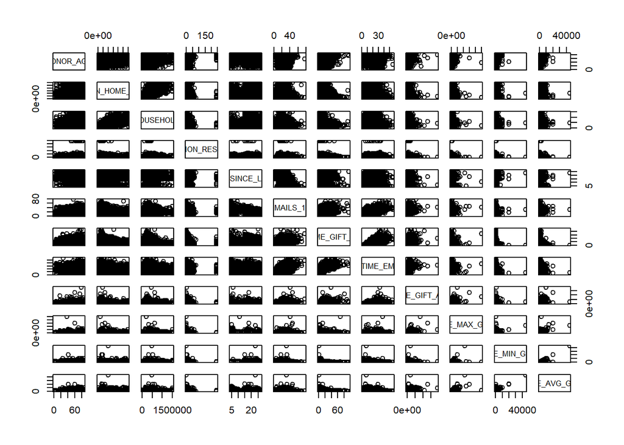

```r
pairs(df[, donor_numeric_index])  # Scatterplot matrix
```

## 3. Identify Outliers

### 3.1 starting mean with `na.rm = T`

```r
df_num <- df[,donor_numeric_index]
df.mean <- sapply(df_num, mean, na.rm = T)
cat("Average value in Feature : \n")
```

```
## Average value in Feature :
```

```r
print(round(df.mean))
```

```
##               DONOR_AGE       MEDIAN_HOME_VALUE MEDIAN_HOUSEHOLD_INCOME
##                      59                 1079872                  341970
##       DONATION_RESPONSE  MONTHS_SINCE_LAST_GIFT               EMAILS_12
##                       3                      18                      18
##     LIFETIME_GIFT_COUNT         LIFETIME_EMAILS    LIFETIME_GIFT_AMOUNT
##                      10                      19                   10443
##   LIFETIME_MAX_GIFT_AMT   LIFETIME_MIN_GIFT_AMT   LIFETIME_AVG_GIFT_AMT
##                    1921                     762                    1286
```

### 3.2 Calculate Z-score value to define outliers

```r
df.zScr <- df_num
df.zScr <- as.data.frame(lapply(df_num, function(x){
  col.mean <- mean(x, na.rm = T)
  col.sd <-sd(x, na.rm = T)
  col.zScr <- ifelse(!is.na(x), (x - col.mean)/col.sd, NA)
  return(col.zScr)
}))
# confirm correct results
head(df.zScr, 5)
```

|  | DONOR_AGE | MEDIAN_HOME_VALUE | MEDIAN_HOUSEHOLD_INCOME | DONATION_RESPONSE | MONTHS_SINCE_LAST_GIFT | EMAILS_12 | LIFETIME_GIFT_COUNT | LIFETIME_EMAILS | LIFETIME_GIFT_AMOUNT | LIFETIME_MAX_GIFT_AMT | LIFETIME_MIN_GIFT_AMT | LIFETIME_AVG_GIFT_AMT |
| --- | --- | --- | --- | --- | --- | --- | --- | --- | --- | --- | --- | --- |
| 1 | 1.6845825 | -0.5473537 | -0.29213114 | -0.3537289 | 1.93620688 | -0.2289937 | 2.8798072 | 0.03878151 | 1.82150778 | 0.04913891 | -0.3292717 | -0.4970936 |
| 2 | 1.2046607 | -0.7763406 | -0.79149839 | -0.3537289 | -2.77485058 | 1.7559846 | 1.7288160 | 1.55768990 | 2.49307748 | 0.35967617 | -0.3292717 | 0.2118472 |
| 3 | 0.9646998 | 1.3615648 | 0.38384159 | -0.3537289 | -3.02280097 | 4.4627731 | 2.9949064 | 2.95975919 | 4.71587857 | 0.54599852 | -0.3292717 | 0.4428504 |
| 4 | NA | 0.6329700 | -1.15079921 | -0.3537289 | -3.02280097 | 4.6432257 | 3.1100055 | 1.44085080 | 3.12681226 | -0.13718344 | -0.5805348 | -0.1249850 |
| 5 | 0.9047095 | -0.5889877 | -0.08507643 | 0.4880679 | -0.04739626 | 1.2146269 | 0.2325273 | 1.32401169 | 0.01489072 | 0.35967617 | -0.3292717 | -0.4584034 |

### 3.3 Number of Outliers by Column

```r
# store outlier index for later
outliers <- vector('list')
outlier_values <- vector('list')

for (col in colnames(df.zScr)) {
  # Find outliers where |z| > 3 for a base eval df.zScr
  z_Sc <- df.zScr[[col]]
  idx <- which(abs(z_Sc) > 3)
  if(length(idx) > 0){
    cat(col, " has : \n")
    cat("\t", length(idx), " outliers with z-score > |3.0|\n")

    # save index
    outliers[[col]] <- idx
    outliers_3 <- round(z_Sc[idx], 2)

    #mean/range
    mean_zSc <- mean(outliers_3, na.rm = T)
    abs_mean_zSc <- mean(abs(outliers_3), na.rm = T)
    cat("\t mean  : ", mean_zSc, "\n")
    cat("\t abs(z) mean : ", round(abs_mean_zSc, 2), "\n")
    cat("\t range : [",paste0(range(outliers_3, na.rm = T),
                              collapse = ", "),"]\n\n")

    # store unique value and counts for outliers
    outlier_values[[col]] <- table(df_num[idx, col], useNA = 'ifany')
  } else {
    cat(col, " has no outliers. \n\n")
  }
}
```

```
## DONOR_AGE  has :
##   90  outliers with z-score > |3.0|
##   mean  :  -3.138
##   abs(z) mean :  3.14
##   range : [ -3.53, -3.11 ]
##
## MEDIAN_HOME_VALUE  has :
##   501  outliers with z-score > |3.0|
##   mean  :  4.088583
##   abs(z) mean :  4.09
##   range : [ 3, 5.12 ]
##
## MEDIAN_HOUSEHOLD_INCOME  has :
##   258  outliers with z-score > |3.0|
##   mean  :  4.35438
##   abs(z) mean :  4.35
##   range : [ 3.01, 7.05 ]
##
## DONATION_RESPONSE  has :
##   218  outliers with z-score > |3.0|
##   mean  :  5.405917
##   abs(z) mean :  5.41
##   range : [ 3.01, 25.01 ]
##
## MONTHS_SINCE_LAST_GIFT  has :
##   575  outliers with z-score > |3.0|
##   mean  :  -3.275217
##   abs(z) mean :  3.28
##   range : [ -3.52, -3.02 ]
##
## EMAILS_12  has :
##   604  outliers with z-score > |3.0|
##   mean  :  3.891904
##   abs(z) mean :  3.89
##   range : [ 3.02, 10.6 ]
##
## LIFETIME_GIFT_COUNT  has :
##   298  outliers with z-score > |3.0|
##   mean  :  4.11349
##   abs(z) mean :  4.11
```

[output cut: 16 more lines]

```
##   mean  :  6.5808
##   abs(z) mean :  6.58
##   range : [ 3.15, 60.91 ]
##
## LIFETIME_MIN_GIFT_AMT  has :
##   114  outliers with z-score > |3.0|
##   mean  :  6.585614
##   abs(z) mean :  6.59
##   range : [ 3.19, 55.58 ]
##
## LIFETIME_AVG_GIFT_AMT  has :
##   214  outliers with z-score > |3.0|
##   mean  :  5.583785
##   abs(z) mean :  5.58
##   range : [ 3.02, 49.74 ]
```

### 3.4 Outlier Table Counts of Numeric Feature Values

```r
for(x in names(outlier_values)){
  tbl <- outlier_values[[x]]
  indxMax <- which.max(tbl)
  indxMin <- which.min(tbl)
  cat(x, "Feature Outliers: \n")
  mean_out <- round(mean(df[outliers[[x]], x], na.rm = T),2)
  cat("\t outlier mean  : ", mean_out, "\n")
  cat("\t mode  : ", names(tbl)[indxMax] , " with ", max(tbl), " entries\n\n")

  mean_ov <- mean(df[[x]], na.rm = T)
  cat("\t Overall mean : ", mean_ov, "\n\n")
  values_wo <- df[-outliers[[x]], x]
  range_wo <- range(values_wo, na.rm = T)
  mean_wo <- round(mean(values_wo, na.rm = T),2)
  cat("\t Without Outliers : \n")
  cat("\t mean : ", mean_wo, "\n")
  cat("\t range : [",paste0(range(range_wo, na.rm = T),
                              collapse = ", "),"]\n\n")
}
```

```
## DONOR_AGE Feature Outliers:
##   outlier mean  :  6.53
##   mode  :  7  with  74  entries
##
##   Overall mean :  58.91905
##
##   Without Outliers :
##   mean :  59.24
##   range : [ 12, 87 ]
##
## MEDIAN_HOME_VALUE Feature Outliers:
##   outlier mean  :  5008166
##   mode  :  5e+06  with  25  entries
##
##   Overall mean :  1079872
##
##   Without Outliers :
##   mean :  975580.9
##   range : [ 0, 3960000 ]
##
## MEDIAN_HOUSEHOLD_INCOME Feature Outliers:
##   outlier mean  :  1057081
##   mode  :  1500000  with  24  entries
##
##   Overall mean :  341970.2
##
##   Without Outliers :
##   mean :  332317.7
##   range : [ 0, 833000 ]
##
## DONATION_RESPONSE Feature Outliers:
##   outlier mean  :  54.74
##   mode  :  32  with  23  entries
##
##   Overall mean :  3.361656
##
##   Without Outliers :
##   mean :  2.78
##   range : [ 0, 31 ]
##
```

[output cut: 64 more lines]

```
##   Overall mean :  762.0932
##
##   Without Outliers :
##   mean :  731.05
##   range : [ 0, 3000 ]
##
## LIFETIME_AVG_GIFT_AMT Feature Outliers:
##   outlier mean  :  6191.48
##   mode  :  5000  with  56  entries
##
##   Overall mean :  1285.834
##
##   Without Outliers :
##   mean :  1231.04
##   range : [ 136, 3917 ]
```

### 3.6 Calculate Mean to Impute for Outliers

The overall mean and the mean without outliers are both fairly close with outliers counterbalancing in a way,but outliers need to be removed due to multiple very extreme values.

```r
# initialize ne df to impute
df.imputed <- df_num

df.imputed <- as.data.frame(lapply(colnames(df_num), function(x){
  out.val <- unlist(outliers[x])
  col.mean <- mean(df_num[,x], na.rm = T) # mean to impute
  df.imputed[out.val, x] <- as.integer(col.mean)
  return(df.imputed[,x])
  }))

# overwrite colnames
colnames(df.imputed) <- colnames(df_num)

for(c in colnames(df_num)){
  if(c %in% colnames(df.imputed)){
    df[,c] <- df.imputed[,c] # impute applied to df
  }
}

head(df,3)
```

|  | DONATED | DONOR_AGE | URBANICITY | DONOR_GENDER | HOME_OWNER | INCOME_LEVEL | SES | MEDIAN_HOME_VALUE | MEDIAN_HOUSEHOLD_INCOME | DONATION_RESPONSE | MONTHS_SINCE_LAST_GIFT | EMAILS_12 | LIFETIME_GIFT_COUNT | LIFETIME_EMAILS | LIFETIME_GIFT_AMOUNT | LIFETIME_MAX_GIFT_AMT | LIFETIME_MIN_GIFT_AMT | LIFETIME_AVG_GIFT_AMT |
| --- | --- | --- | --- | --- | --- | --- | --- | --- | --- | --- | --- | --- | --- | --- | --- | --- | --- | --- |
| 1 | FALSE | 87 | ? | M | H | 2 | . | 554000 | 294000 | 0 | 26 | 17 | 35 | 19 | 29700 | 2000 | 500 | 849 |
| 2 | TRUE | 79 | R | M | H | 7 | 45 | 334000 | 212000 | 0 | 7 | 28 | 25 | 32 | 36800 | 2500 | 500 | 1472 |
| 3 | FALSE | 75 | S | F | H | 5 | 11 | 2388000 | 405000 | 0 | 18 | 18 | 36 | 44 | 10442 | 2800 | 500 | 1675 |

## 4. Remove Missing Values

### 4.1 `NA` Missing Values

From the `str( )`, `summary( )` and preliminary feature overview, there are currently features that correspond to `NA` and empty strings `''`. This means remaining features do *not* have `NA` or `''` values**. There are a few possibilities to explain the *lack* of ‘missing values’:

- There are no ‘missing values’ in those features (unlikely)
- There is a *default value* applied to entries of another column because of an equivalency or correlation for no response and the *default*
- There is a *substitute value* in place to indicate a ‘missing value’.

### 4.2 Number of Missing Values by Feature

```r
#initialize object as false for print
found <- F
num.Missing.Values <- vector('numeric', length = ncol(df))
# save NA for end reference
df_NAlist <- vector('list')

for(c in colnames(df)){
  missing.Values <- which(is.na(df[[c]]))
  num.Missing.Values <- length(missing.Values)

  if(num.Missing.Values > 0){
    cat(c, " has ", num.Missing.Values, " missing values.\n")
    found <- T
  }else{
    next
  }
  if(c %in% donor_categoric_name){
    # categories impute mode
    mode.t <- table(df[c])
    max.modeNOTNA <- names(mode.t)[which.max(mode.t)]
    df[missing.Values, c] <- max.modeNOTNA
    cat("\t Impute Mode : ", max.modeNOTNA, " \n\n")

    } else {
    # impute mean for numeric that aren't categories
    df[missing.Values, c] <- as.integer(mean(df[,c], na.rm = T))
    cat("\t Impute Mean : ", as.integer(mean(df[,c], na.rm = T)), " \n\n")
    }
}
```

```
## DONOR_AGE  has  4795  missing values.
##   Impute Mean :  59
##
## INCOME_LEVEL  has  4392  missing values.
##   Impute Mode :  5
```

Similarly these values that are NA will need to be imputed, the mean will still be used as it serves as somewhat of a smoothing. The categorical features were imputed with the Mode (Income was the only one with a scale 1:7).

### 4.3. Substitute `character` Missing Values

- **Notable Exception for “U” assignment:**
  - `URBANICITY` : ‘U’ indicates “Urban” while “?” is the unknown level category of the feature
  - `DONOR_GENDER` : ‘U’ in the Data Dictionary is indicated as “unknown”; however in the spirit of inclusivity, the *unknown* will be treated as ‘unknown/other/non-binary’.But it will still be used assigned as “NA” for consistency. The feature level is broadened to include any person that does not want to disclose their gender identity, a person who’s gender identity is not ‘male’ or ‘female’, or a true ‘missing value’ that was accidentally skipped. Because of this the *missingness* is unknown, it would be difficult to attribute it to a specific cause (random or otherwise) and would make ‘U’ be more akin to a *default value* if no significant indicator feature that is highly correlation to ‘male’ or ‘female’ is found. Either way this will likely make the feature difficult to be helpful in prediction.

#### 4.3.1 make all Substitute NA values into character “unknown” for easier ID

## Ideally would have Replace `LIFETIME` Values ahead

From the `summary( )` features have a minimum value of `0`, upon further evaluation the features with a minimum value equal to `0` had the presence of `0` tallied. While some features appear to make sense, others (while unlikely) are at least possible, but for some features a `0` is impossible.

#### Unlikely & Boarders not-possible : leave `0` for now

- `DONOR_AGE` **cannot be `0`** as that would be a newborn baby. But any age that corresponds to a **“minor”** (by US cutoff 18) *should be evaluated.*
  1. There is a possibility a donation was placed with the permission or help of the minor’s guardian or even placed by the guardian in honor of the minor. Either way there are possible ways for a minor to contribute to a donation : be it from a guardian or earned income (for minor’s above 14 by US regulation to have a job). But this is very unlikely to be recorded under a minor for a donation registrar and are most likely a data entry error.
  2. However, `NA` values are already present in the column, indicating that `0` is not a “substitute value”, and therefore the idea of *data entry error* is more plausible. Because of this, I do think waiting to change the `0` value to `NA` until after correlation and imputation of `NAs` occur, where these would be handled along with other unlikely values in the “outliers section.”

#### Possible Legitimate Value & Potentially “Default” Value : leave `0` for now

`MEDIAN*` value can only be `0` if no value was reported for the metric being measured since ‘median’ indicates a middle value between reported upper and lower bounds. This alludes to *two monetary possibilities* :

1. Either the individual has positive (income) and negative (debt/bills) monetary measures to evaluated, which result in the net value to be `0`. While this is a valid concept, is not really relevant or applicable to the “Donor Data Features” provided.
2. This leaves the other possibility: ‘median’ is derived from (upper and lower bounds), indicating that the *corresponding features it is derived from are `0`.* The corresponding features could potentially have `NA`, where `0` is applied as a default correlated response; but the question of if 1 or Both need to have `NA` to result in `0` due to *missingness*.

I lean towards `0` is an actual monetary value assessment that is an indication of the correlated features it is derived from, which also means I believe this is a derived calculation rather than manual input for *income* and *home value* that go beyond *missingness.*

- `MEDIAN_HOME_VALUE` : `0` would likely indicate no home *ownership* because if you don’t own a home the value is not an indicator of the ‘donor’ so likely this corresponds to the feature `HOME_OWNER = FALSE`. In which case, the `0` is a monetary assessment since not owning something has a value of `0`. Having zero present in data will skew the distribution, I was inclined to impute `NA` since `0` is not a good indicator for *missingness* when evaluating the distributions, but imputing `NA` could cause a wrong assessment that a value was not entered and instead a wrongly imputed value might be assign to a person that does not own a home and therefore meant `0` value.
- `MEDIAN_HOUSEHOLD_INCOME` : The donor could be a minor or unable to generate income because under 14 work limitations [by U.S.](https://www.dol.gov/general/topic/youthlabor/agerequirements), someone past retirement without an *earned* income where other financial support is not accounted as income, or generally just unemployed. The `0` would likely correspond to a specific level of another feature such as `DONOR_AGE`, `INCOME_LEVEL`, or “SES”. Because income already has `NA` values present do not impute `NA` as it would have a different meaning than `0` income, it could also be a ‘default’ applied if the `INCOME_LEVEL` is `NA` which is currently observed.

These `0` values have a very high likelihood to correspond with another feature(s), so leaving it as `0` until a correlation to other feature values can be assessed is the best approach. Again if this is treated as a ‘default’ for ‘missingness’ it could cause imputation to be applied and alter the true representation of the data. Assessing correlation before imputation to find a best imputation method is best approach. This correlated relation could lead to specific “decision rules” being best over methods like kNN or Naive Bayes. For now, leave as `0` with this in mind.

#### Not Possible : `0` is Missing Value : impute `NA`

**`LIFETIME_GIFT_COUNT` = minimum of 1 Donation.** This means that all individuals on this list have donated something in the *lifetime of this list*. This confirms the “Data Dictionary Definition” that `TRUE` and `FALSE` for the `DONATED` feature column is respective to the *most recent campaign*, not an indicator of whether the donor has *ever* donated. This also means that a `0` dollar amount is not possible for any of the `LIFETIME*` features. By definition a donation is a ‘gift’ and any value that is `0` cannot be considered a donation contribution, **which means a donation value must be greater than `0` dollars. This means that any derived `LIFETIME` feature below cannot = 0**

The indicates that `0` is not a legitimate monetary value and rather represent an “unknown” value that should be handled according to overall missingness and relation to other features. With all `LIFETIME*` Features being derivative calculations of each other, the best approach without compounding correlation (multicollinearity) effect for a predictive model would be to make one of the “monetary assessments” be complete and the utilized predictive feature, where the potential of a complete count of timeframe to be incorporated.

- `LIFETIME*` features appear to be derived values dependent on other features. The correlation should be evaluated so that all highly correlated “Lifetime*” features are excluded from predictive modeling process. But the highly dependent relationship might prove useful for imputing missing values. These will remain in the `df` for now.

$$\text{LIFETIME_AVG_GIFT_AMT} =
\frac{\text{LIFETIME_GIFT_AMT}}{\text{LIFETIME_GIFT_COUNT}}$$
Therefore :
$$\text{LIFETIME_GIFT_AMT} =
\text{LIFETIME_AVG_GIFT_AMT}\:\times\:\text{LIFETIME_GIFT_COUNT}$$

`LIFETIME_MAX_GIFT_AMT` must be $\geq$ to `LIFETIME_MIN_GIFT_AMT`  
`LIFETIME_MIN_GIFT_AMT` must be $\leq$ to `LIFETIME_MAX_GIFT_AMT`

If :
$$\text{LIFETIME_MIN_GIFT_AMT} ==
\text{LIFETIME_MAX_GIFT_AMT}$$
Then :
$$\text{BOTH} ==
\text{LIFETIME_AVG_GIFT_AMT}$$
Otherwise `LIFETIME_AVG_GIFT_AMT` is between Both.

- `LIFETIME_EMAIL_12` : I don’t know if `0` emails is possible in this data set but I will presume the minimum is `1` as part of a “Welcome” or “Thank You” message for the initial donation made that placed the individual in this list. It makes sense as a concept for emails specifically, but also all other `LIFETIME*` features must be `1` at minimum because of the minimum donation given. Therefore the the support range of the feature is likely [1, Inf) though Inf is unrealistic.

## Numeric Conversion and Integer Equivalence Test Make Dataset More Uniform for Processing :

The `NA`, `''`, and `0` values have all been evaluated and substituted as was deemed appropriate, but from the `str()` and manual visual assessment of `df` many values appear to be *discrete numeric values.*

Initially the data.frame had : many feature types. Based on the visual inspection of `df` and the preliminary data exploration, all `double` numeric values appeared to be integer and even `character` values seems to be `numeric` values. Additionally the `LIFETIME*` features are not consistent for `num` or `int` identifier, which seems unlikely based on no association of derived features to `num`.

## 5. Encode Features For GLM and RandomForest

URBANICITY  
- DONOR_GENDER  
- HOME_OWNER  
- INCOME_LEVEL  
- SES

### 5.0 Make “Unkown” Categories Uniform

This will make processing later easier because all true “unknown” categories have the same label. Except the ordinal ‘SES’(INCOME_LEVEL had no missing values). The glm requires numeric data for proccessing and so does the Pearson’s Correlation Coeffient. So use frequency encoding to limit number of columns.

```r
category_tbl <- vector('list')
for(c in donor_categoric_name){

  if(c %in% c('DONOR_GENDER', 'HOME_OWNER', 'SES')){
    index_SN <- which(df[,c] %in% c('?', '.', 'U'))
    cat(c)
    df[index_SN,c] <- ifelse(c %in% ordinal_features, NA, "unknown")

  } else if ((c == 'URBANICITY') == T){
    index_SN <- which(df[,c] %in% c('?', '.'))
    cat(c)
    df[index_SN, c] <- "unknown"
  }
  category_tbl[[c]] <- tbl <- table(df[[c]] , useNA = 'ifany')
  print(tbl)
  cat("\t ", length(tbl), " : unique values categories \n")
  cat("\t ", max(tbl), " entries = ", names(tbl)[which.max(tbl)], " (mode)\n\n")
  }
```

```
## URBANICITY
##       C       R       S       T       U unknown
##    4022    4005    4491    3944    2456     454
##    6  : unique values categories
##    4491  entries =  S  (mode)
##
## DONOR_GENDER
##       F       M unknown
##    9984    7633    1755
##    3  : unique values categories
##    9984  entries =  F  (mode)
##
## HOME_OWNER
##       H       N unknown
##    9456    2151    7765
##    3  : unique values categories
##    9456  entries =  H  (mode)
##
##
##    1    2    3    4    5    6    7
## 1822 2626 1699 2526 7541 1591 1567
##    7  : unique values categories
##    7541  entries =  5  (mode)
##
## SES
##    1   10   11   12   13   14   15   16   17   18   19    2   20   21   22   23
##  239  387  484  631  579  454  223  384  349  619   98  380  317  353  251  293
##   24   25   26   27   28   29    3   30   31   32   33   34   35   36   37   38
##  795  273  202  666  343  170  300  519  249  152  109  284  727  716  204  240
##   39    4   40   41   42   43   44   45   46   47   48   49    5   50   51   52
##  512  113  830  431  284  468  383  482  369  185  180  675  199  156  460   60
##   53    6    7    8    9 <NA>
##  303  123  184  378  153  454
##    54  : unique values categories
##    830  entries =  40  (mode)
```

## 5.1 GLM Encoding

### 5.1 Target : DONATED : Numeric until after Pearson’s

```r
# factor target after pearson correlation ; numeric for test
df$DONATED <- ifelse(df$DONATED == TRUE, 1, 0)
```

### 5.2 Categories as Factors

#### SES and INCOME_LEVEL : Numeric to Keep some Magnitude of Direction

```r
## encode SES
df$SES <- as.numeric(df$SES)
df$SES[which(is.na(df$SES))] <- 0
# encode Income Level
df$INCOME_LEVEL <- as.numeric(df$INCOME_LEVEL)
```

#### DONOR_GENDER, HOME_OWNER, URBANICITY : frequencies to be Numeric though it will ccause slight ordinality

```r
df.preFreqEncode <- df
encode_f <- c('DONOR_GENDER', 'HOME_OWNER', 'URBANICITY')
for(c in encode_f){
  col <- df[[c]]
  values <- table(col)
  for(v in 1:length(values)){
    idx <- which(col == names(values)[v])
    freq <- values[v]/nrow(df)
    col[idx] <- freq
  }
  df[[c]] <- as.numeric(col)
}
```

## 6. Multicollinearity

### 6.1 Pearson’s Correlation Matrix :

Numeric values below 0.4 are weak , 0.4-0.7 are moderate and above 0.7 is strong. The data is not needed to be normal for the glm or random forest models, but some linear relation between features after a function transform in glm is assumed. Random Forest is mainly a split delimiter where the end leaves’s purity is assessed. The data set is large so a larger tree is likely needed.

```r
cor_matrix <- cor(df, use = "pairwise.complete", method = "pearson")
kable(cor_matrix, caption = "Pearson's Correlation Coefficient for Features")
```

Pearson’s Correlation Coefficient for Features

|  | DONATED | DONOR_AGE | URBANICITY | DONOR_GENDER | HOME_OWNER | INCOME_LEVEL | SES | MEDIAN_HOME_VALUE | MEDIAN_HOUSEHOLD_INCOME | DONATION_RESPONSE | MONTHS_SINCE_LAST_GIFT | EMAILS_12 | LIFETIME_GIFT_COUNT | LIFETIME_EMAILS | LIFETIME_GIFT_AMOUNT | LIFETIME_MAX_GIFT_AMT | LIFETIME_MIN_GIFT_AMT | LIFETIME_AVG_GIFT_AMT |
| --- | --- | --- | --- | --- | --- | --- | --- | --- | --- | --- | --- | --- | --- | --- | --- | --- | --- | --- |
| DONATED | 1.0000000 | 0.0289840 | -0.0010221 | 0.0019538 | 0.0135603 | 0.0341908 | -0.0193875 | 0.0491373 | 0.0366042 | 0.0229156 | -0.0712485 | 0.0191731 | 0.1000130 | 0.0640985 | 0.0489649 | -0.0871247 | -0.0806775 | -0.0976168 |
| DONOR_AGE | 0.0289840 | 1.0000000 | -0.0171933 | -0.0216175 | -0.0999568 | -0.1781248 | 0.0109457 | -0.0090310 | -0.0668772 | 0.1304388 | -0.0505931 | 0.0566463 | 0.1906071 | 0.2012679 | 0.1582590 | -0.0364883 | -0.1179818 | -0.0879873 |
| URBANICITY | -0.0010221 | -0.0171933 | 1.0000000 | 0.0108158 | 0.0176015 | 0.0303455 | 0.4292486 | -0.0901595 | 0.0697458 | 0.0344209 | 0.0266989 | -0.0324941 | -0.0288100 | -0.0114647 | -0.0232684 | -0.0040425 | -0.0031951 | -0.0028458 |
| DONOR_GENDER | 0.0019538 | -0.0216175 | 0.0108158 | 1.0000000 | -0.0008457 | -0.0502217 | -0.0065622 | -0.0017930 | -0.0042208 | 0.0341058 | -0.0008566 | 0.0090679 | -0.0083484 | -0.0177907 | -0.0180138 | -0.0251302 | -0.0092377 | -0.0210957 |
| HOME_OWNER | 0.0135603 | -0.0999568 | 0.0176015 | -0.0008457 | 1.0000000 | 0.4556486 | -0.1041674 | 0.1371965 | 0.1937255 | 0.0327446 | 0.0250656 | 0.0081657 | -0.0539155 | -0.0275502 | -0.0131798 | 0.0499594 | 0.0429030 | 0.0621487 |
| INCOME_LEVEL | 0.0341908 | -0.1781248 | 0.0303455 | -0.0502217 | 0.4556486 | 1.0000000 | -0.1716298 | 0.2758624 | 0.3485831 | -0.0694465 | 0.0399351 | -0.0225666 | -0.1067556 | -0.0673977 | -0.0262996 | 0.0923399 | 0.0838090 | 0.1155025 |
| SES | -0.0193875 | 0.0109457 | 0.4292486 | -0.0065622 | -0.1041674 | -0.1716298 | 1.0000000 | -0.4454036 | -0.3618490 | -0.0481276 | 0.0060121 | -0.0119154 | 0.0532401 | 0.0493412 | 0.0050103 | -0.0572634 | -0.0746829 | -0.0843427 |
| MEDIAN_HOME_VALUE | 0.0491373 | -0.0090310 | -0.0901595 | -0.0017930 | 0.1371965 | 0.2758624 | -0.4454036 | 1.0000000 | 0.6011494 | 0.0120078 | -0.0060168 | 0.0197393 | -0.0594863 | -0.0367344 | 0.0106754 | 0.0767572 | 0.0787823 | 0.1002336 |
| MEDIAN_HOUSEHOLD_INCOME | 0.0366042 | -0.0668772 | 0.0697458 | -0.0042208 | 0.1937255 | 0.3485831 | -0.3618490 | 0.6011494 | 1.0000000 | 0.0578254 | 0.0048210 | 0.0107119 | -0.0628830 | -0.0274336 | 0.0038311 | 0.0694457 | 0.0647946 | 0.0849564 |
| DONATION_RESPONSE | 0.0229156 | 0.1304388 | 0.0344209 | 0.0341058 | 0.0327446 | -0.0694465 | -0.0481276 | 0.0120078 | 0.0578254 | 1.0000000 | -0.0088876 | 0.0256878 | 0.0647799 | 0.0858948 | 0.0488340 | -0.0102725 | -0.0399512 | -0.0288314 |
| MONTHS_SINCE_LAST_GIFT | -0.0712485 | -0.0505931 | 0.0266989 | -0.0008566 | 0.0250656 | 0.0399351 | 0.0060121 | -0.0060168 | 0.0048210 | -0.0088876 | 1.0000000 | -0.2841500 | -0.1050442 | -0.0129912 | -0.0269358 | 0.1158163 | 0.0956252 | 0.1256981 |
| EMAILS_12 | 0.0191731 | 0.0566463 | -0.0324941 | 0.0090679 | 0.0081657 | -0.0225666 | -0.0119154 | 0.0197393 | 0.0107119 | 0.0256878 | -0.2841500 | 1.0000000 | 0.2199045 | 0.3296842 | 0.2742385 | 0.0873748 | -0.1882020 | -0.0385836 |
| LIFETIME_GIFT_COUNT | 0.1000130 | 0.1906071 | -0.0288100 | -0.0083484 | -0.0539155 | -0.1067556 | 0.0532401 | -0.0594863 | -0.0628830 | 0.0647799 | -0.1050442 | 0.2199045 | 1.0000000 | 0.7866640 | 0.6822967 | -0.1918367 | -0.5222885 | -0.4361013 |
| LIFETIME_EMAILS | 0.0640985 | 0.2012679 | -0.0114647 | -0.0177907 | -0.0275502 | -0.0673977 | 0.0493412 | -0.0367344 | -0.0274336 | 0.0858948 | -0.0129912 | 0.3296842 | 0.7866640 | 1.0000000 | 0.7246998 | -0.0074936 | -0.5286468 | -0.3074851 |
| LIFETIME_GIFT_AMOUNT | 0.0489649 | 0.1582590 | -0.0232684 | -0.0180138 | -0.0131798 | -0.0262996 | 0.0050103 | 0.0106754 | 0.0038311 | 0.0488340 | -0.0269358 | 0.2742385 | 0.6822967 | 0.7246998 | 1.0000000 | 0.2661618 | -0.2725706 | 0.0275323 |
| LIFETIME_MAX_GIFT_AMT | -0.0871247 | -0.0364883 | -0.0040425 | -0.0251302 | 0.0499594 | 0.0923399 | -0.0572634 | 0.0767572 | 0.0694457 | -0.0102725 | 0.1158163 | 0.0873748 | -0.1918367 | -0.0074936 | 0.2661618 | 1.0000000 | 0.3643940 | 0.7520554 |
| LIFETIME_MIN_GIFT_AMT | -0.0806775 | -0.1179818 | -0.0031951 | -0.0092377 | 0.0429030 | 0.0838090 | -0.0746829 | 0.0787823 | 0.0647946 | -0.0399512 | 0.0956252 | -0.1882020 | -0.5222885 | -0.5286468 | -0.2725706 | 0.3643940 | 1.0000000 | 0.7610562 |
| LIFETIME_AVG_GIFT_AMT | -0.0976168 | -0.0879873 | -0.0028458 | -0.0210957 | 0.0621487 | 0.1155025 | -0.0843427 | 0.1002336 | 0.0849564 | -0.0288314 | 0.1256981 | -0.0385836 | -0.4361013 | -0.3074851 | 0.0275323 | 0.7520554 | 0.7610562 | 1.0000000 |

### 6.2 Pearson’s Correlation Quick Reference

```r
df.Cor_labeled <- as.data.frame(apply(cor_matrix, c(1,2), function(x){
  new_label <- cut(x,
                   breaks = c(-Inf, 0.2, 0.4, 0.7, 0.99, 1),
                   labels = c("-","weak", "moderate", "REMOVE", "(self)"))
  return(new_label)
  }))
# make data frame to print
kable(df.Cor_labeled, caption = "Cut off 0.7 for strong ccorrelation")
```

Cut off 0.7 for strong ccorrelation

|  | DONATED | DONOR_AGE | URBANICITY | DONOR_GENDER | HOME_OWNER | INCOME_LEVEL | SES | MEDIAN_HOME_VALUE | MEDIAN_HOUSEHOLD_INCOME | DONATION_RESPONSE | MONTHS_SINCE_LAST_GIFT | EMAILS_12 | LIFETIME_GIFT_COUNT | LIFETIME_EMAILS | LIFETIME_GIFT_AMOUNT | LIFETIME_MAX_GIFT_AMT | LIFETIME_MIN_GIFT_AMT | LIFETIME_AVG_GIFT_AMT |
| --- | --- | --- | --- | --- | --- | --- | --- | --- | --- | --- | --- | --- | --- | --- | --- | --- | --- | --- |
| DONATED | (self) | - | - | - | - | - | - | - | - | - | - | - | - | - | - | - | - | - |
| DONOR_AGE | - | (self) | - | - | - | - | - | - | - | - | - | - | - | weak | - | - | - | - |
| URBANICITY | - | - | (self) | - | - | - | moderate | - | - | - | - | - | - | - | - | - | - | - |
| DONOR_GENDER | - | - | - | (self) | - | - | - | - | - | - | - | - | - | - | - | - | - | - |
| HOME_OWNER | - | - | - | - | (self) | moderate | - | - | - | - | - | - | - | - | - | - | - | - |
| INCOME_LEVEL | - | - | - | - | moderate | (self) | - | weak | weak | - | - | - | - | - | - | - | - | - |
| SES | - | - | moderate | - | - | - | (self) | - | - | - | - | - | - | - | - | - | - | - |
| MEDIAN_HOME_VALUE | - | - | - | - | - | weak | - | (self) | moderate | - | - | - | - | - | - | - | - | - |
| MEDIAN_HOUSEHOLD_INCOME | - | - | - | - | - | weak | - | moderate | (self) | - | - | - | - | - | - | - | - | - |
| DONATION_RESPONSE | - | - | - | - | - | - | - | - | - | (self) | - | - | - | - | - | - | - | - |
| MONTHS_SINCE_LAST_GIFT | - | - | - | - | - | - | - | - | - | - | (self) | - | - | - | - | - | - | - |
| EMAILS_12 | - | - | - | - | - | - | - | - | - | - | - | (self) | weak | weak | weak | - | - | - |
| LIFETIME_GIFT_COUNT | - | - | - | - | - | - | - | - | - | - | - | weak | (self) | REMOVE | moderate | - | - | - |
| LIFETIME_EMAILS | - | weak | - | - | - | - | - | - | - | - | - | weak | REMOVE | (self) | REMOVE | - | - | - |
| LIFETIME_GIFT_AMOUNT | - | - | - | - | - | - | - | - | - | - | - | weak | moderate | REMOVE | (self) | weak | - | - |
| LIFETIME_MAX_GIFT_AMT | - | - | - | - | - | - | - | - | - | - | - | - | - | - | weak | (self) | weak | REMOVE |
| LIFETIME_MIN_GIFT_AMT | - | - | - | - | - | - | - | - | - | - | - | - | - | - | - | weak | (self) | REMOVE |
| LIFETIME_AVG_GIFT_AMT | - | - | - | - | - | - | - | - | - | - | - | - | - | - | - | REMOVE | REMOVE | (self) |

### 6.3 Remove Features and Groupings

Logistic Regression does not assume normality, but any highly correlated features should be removed ahead of time if possible.

```r
keep <- c("DONATED", "DONOR_AGE", "SES", "MEDIAN_HOME_VALUE","DONATION_RESPONSE", "LIFETIME_GIFT_AMOUNT", "LIFETIME_MIN_GIFT_AMT")
df <- df[ ,which(colnames(df) %in% keep)]
# confirm
colnames(df)
```

```
## [1] "DONATED"               "DONOR_AGE"             "SES"
## [4] "MEDIAN_HOME_VALUE"     "DONATION_RESPONSE"     "LIFETIME_GIFT_AMOUNT"
## [7] "LIFETIME_MIN_GIFT_AMT"
```

## pre7. Class Imbalance of Target : More “No” than “Yes”

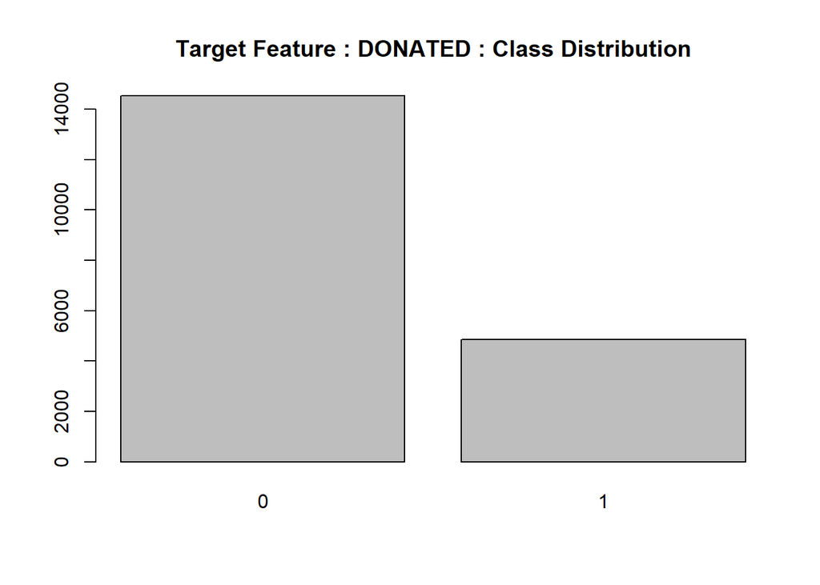

```r
# FALSE  0; TRUE = 1
plot(as.factor(df$DONATED), main = "Target Feature : DONATED : Class Distribution")
```